# Linear & multiple regression

## Linear regression

Linear regression with one independent variable assumes the model

$$y_i = \beta_0 + \beta_1 x_i + \epsilon_i$$

where $\beta_0$ and $\beta_1$ are the regression coefficients.

Read in the data file 'mtcars.csv'. To study the relation between the weight of a car and its fuel consumption, plot the two variables as shown below.

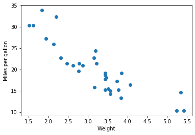

### Estimation of parameters

Linear regression can be performed using the method **LinearRegression()** (module: **sklearn.linear_model**) which is basically the ordinary least squares (OLS) method (equivalently statsmodels' **ols()** does the same). Call **LinearRegression()** and fit a simple linear model for `mpg` as a function of `wt`, and store the model in some variable `model`. Note you may access the coefficient(s) of the model using the attribute `model.coef_` and the intercept using `model.intercept_`. What are the coefficients in this case? Is the slope positive or negative? Add a plot of the model with the estimated coefficients to the previous scatter plot: i.e. use a test set or grid spanning the range of the training data and predict the responses and plot these.

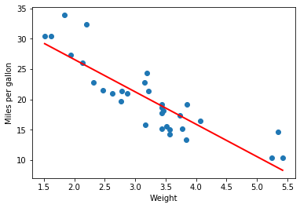

### Diagnostics

To assess the model, we need to study the residuals $y_i - \widehat{y}_i$. There are a number of diagnostic checks we may perform. Here are some:

1. Plot the residuals; is there any apparent pattern or trend? If so, then this would not be a good indication, meaning that our linear model is inaccurate. The residuals are expected to be normally distributed with zero mean and constant variance.
1. To (roughly) check the normality assumption, plot the histogram of the residuals; does it resemble a normal distribution?
1. Furthermore, we may check the normal QQ-plot (i.e. quantile-quantile plot) to see if the actual quantiles follow the theoretical quantiles of the normal distirbution. A QQ-plot in this case can be obtained using scipy's **stats.probplot()** (or statsmodels' **qqplot()**). Do the points follow the QQ-line (i.e. y=x line)? If so, then this gives evidence of a normal distribution.
1. Finally, we may formally test for normality using the Shapiro-Wilk test (hint: **scipy.stats.shapiro()**). Is the p-value low enough to reject the null hypothesis of normality?

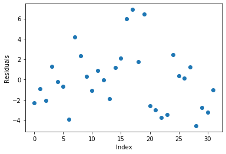

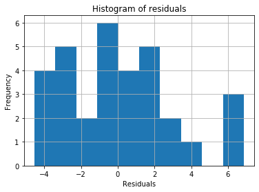

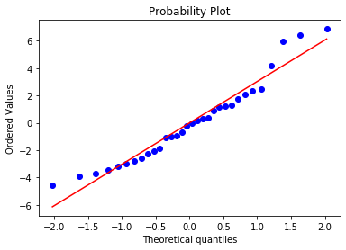

### Identifying outliers

In the context of least-squares regression, we may also examine Cook's distance for each data point. This distance captures the influence of individual points on the resulting regression model by computing the variation in the fitted response when a single data point under consideration is removed from the dataset versus when it is included. This can help us identify outliers which would have a comparatively large influence (Cook's distance) compared to other data points. Compute Cook's distance for each data point and create a plot of these values. Note: Cook's distance can be obtained from a model trained by statsmodels' **ols()** by using the method **get_influence()** and **summary_frame()** (Cook's distance will be one of the columns in the data frame).

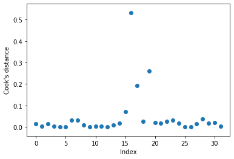

### Prediction

Prediction can be easily performed when we have a model from **ols()**. Prediction intervals with lower and upper limits can be obtained as shown below.

```python
predictions = model.get_prediction(pd.DataFrame(X_test, columns=['wt']))
df = predictions.summary_frame(alpha=0.05) #alpha is the significance level

y_pred = df['mean']
y_lower = df['obs_ci_lower'] #prediction intervals
y_upper = df['obs_ci_upper']
# ...
```

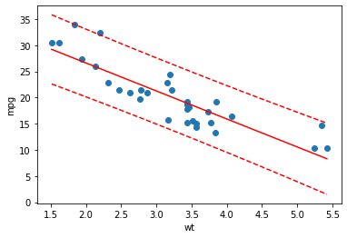

## Multiple regression

Finally, we will study fuel consumption as a function of car weight and horse power. Create a linear model by a call to **LinearRegression()**. Use the model to predict fuel consumption for a new hypothetical car which happens to be heavy (`wt = 3.5`) and with a small engine (`hp=90`). What is the forecasted fuel consumption for this car?